# Working with Categorical Data 2

Billie Anderson, Mark Newman

2020-08-17

# Agenda

- Prior Homework
- Working with data in R (continued)
- Next Homework

# Ordered Factors and Reordered Tables

We are going to return to Example 2.5 that describes job satisfaction classifed by income levels. We create the table first.

```r
JobSat <- matrix(c(1,2,1,0,3,3,6,1,10,10,14,9,6,7,12,11),nrow=4,ncol=4)
JobSat
```

```
##      [,1] [,2] [,3] [,4]
## [1,]    1    3   10    6
## [2,]    2    3   10    7
## [3,]    1    6   14   12
## [4,]    0    1    9   11
```

```r
dimnames(JobSat) <-
  list(
    income=c("< 15k", "15-25k", "25-40k", "> 40k"),
    satisfaction=c("VeryD", "LittleD", "ModerateS", "VeryS"))
JobSat <- as.table(JobSat)
JobSat
```

```
##         satisfaction
## income   VeryD LittleD ModerateS VeryS
##   < 15k      1       3        10     6
##   15-25k     2       3        10     7
##   25-40k     1       6        14    12
##   > 40k      0       1         9    11
```

# Ordered Factors and Reordered Tables (cont.)

Remember, from the Arthritis Data Example, we re-orderd the levels of the variable `Improved.` Factor variables in data frames (case form or frequency form) can be re-ordered and declared as ordered factors using `ordered()`.

The order of the factors themselves can be rearranged by sorting the data frame using `sort()`.

Currently, the way JobSat is defined in table form, the values of the table factors are ordered by their position in the table.

What if we need the levels of income and satisfaction to be numeric variables?

```r
dimnames(JobSat)$income <- c(7.5,20,32.5,60)
dimnames(JobSat)$satisfaction <- 1:4
JobSat
```

```
##       satisfaction
## income  1  2  3  4
##   7.5   1  3 10  6
##   20    2  3 10  7
##   32.5  1  6 14 12
##   60    0  1  9 11
```

You may also want to keep the levels of the variable as character values, but sort them in some order.

```r
dimnames(JobSat)$income <- paste(1:4, dimnames(JobSat)$income, sep=":")
dimnames(JobSat)$satisfaction <- paste(1:4, dimnames(JobSat)$satisfaction, sep=":")
JobSat
```

```
##         satisfaction
## income   1:1 2:2 3:3 4:4
##   1:7.5    1   3  10   6
##   2:20     2   3  10   7
##   3:32.5   1   6  14  12
##   4:60     0   1   9  11
```

# Generating tables with `table()` and `xtabs()`

When the data is in case or frequency form, you can generate frequency tables from factor variables in data frames using the `table()` function.

- for tables of proportions, use `prop.table()`
- for marginal frequenices (summing over variables), use `margin.table()`

# `table()`

Returning to the mydata data frame from section 2.1.

```r
set.seed(12345) # reproducibility
n=100
A <- factor(sample(c("a1","a2"), n, rep=TRUE))
B <- factor(sample(c("b1","b2"), n, rep=TRUE))
sex <- factor(sample(c("M", "F"), n, rep=TRUE))
age <- round(rnorm(n, mean=30, sd=5))
mydata <- data.frame(A, B, sex, age)
str(mydata)
```

```
## 'data.frame':    100 obs. of  4 variables:
##  $ A  : Factor w/ 2 levels "a1","a2": 2 1 2 2 2 2 2 1 1 2 ...
##  $ B  : Factor w/ 2 levels "b1","b2": 1 1 1 2 1 1 1 1 2 1 ...
##  $ sex: Factor w/ 2 levels "F","M": 1 2 1 2 2 2 2 1 2 2 ...
##  $ age: num  22 33 31 26 29 29 38 28 30 27 ...
```

```r
head(mydata)
```

```
##    A  B sex age
## 1 a2 b1   F  22
## 2 a1 b1   M  33
## 3 a2 b1   F  31
## 4 a2 b2   M  26
## 5 a2 b1   M  29
## 6 a2 b1   M  29
```

# `table()` (cont.)

The `table()` functions takes a lists of variables as it’s arguments. The variables are factors. There is no data= argument. So, you must specify the names of columns in the data frame, or select the variables using column indexes.

```r
# 2-way Frequency Table

table(mydata$A, mydata$B) #A will be the rows, B will be the columns
```

```
##
##      b1 b2
##   a1 25 21
##   a2 22 32
```

```r
mytab <- table(mydata[,1:2])   #produces same result
mytab
```

```
##     B
## A    b1 b2
##   a1 25 21
##   a2 22 32
```

# margin.table(X, margin)

Use `margin.table(X, margin)` to sum a table X for the indices in margin, that is, over the dimensions *not* included in margin.

```r
margin.table(mytab) # sum over A & B
```

```
## [1] 100
```

```r
margin.table(mytab, 1) # A frequencies (summed over B)
```

```
## A
## a1 a2
## 46 54
```

```r
margin.table(mytab, 2) # B frequencies (summed over A)
```

```
## B
## b1 b2
## 47 53
```

```r
addmargins(mytab) # show all marginal totals
```

```
##      B
## A      b1  b2 Sum
##   a1   25  21  46
##   a2   22  32  54
##   Sum  47  53 100
```

# `prop.table()`

The function `prop.table()` expresses the table entries as a fraction of a given marginal table.

```r
prop.table(mytab) # cell percentages
```

```
##     B
## A      b1   b2
##   a1 0.25 0.21
##   a2 0.22 0.32
```

```r
prop.table(mytab, 1) # row percentages
```

```
##     B
## A           b1        b2
##   a1 0.5434783 0.4565217
##   a2 0.4074074 0.5925926
```

```r
prop.table(mytab, 2) # column percentages
```

```
##     B
## A           b1        b2
##   a1 0.5319149 0.3962264
##   a2 0.4680851 0.6037736
```

# `table()` (cont.)

`table()` can also generate multidimensional tables based on 3 or more categorical variables. In this case, use the `ftable()` or `structable()` function to print the results more attractively as a (2-way) table.

```r
# 3-Way Frequency Table
mytab <- table(mydata[,c("A", "B", "sex")])
mytab
```

```
## , , sex = F
##
##     B
## A    b1 b2
##   a1 14  8
##   a2  7 18
##
## , , sex = M
##
##     B
## A    b1 b2
##   a1 11 13
##   a2 15 14
```

```r
ftable(mytab)
```

```
##       sex  F  M
## A  B
## a1 b1     14 11
##    b2      8 13
## a2 b1      7 15
##    b2     18 14
```

# `xtabs()`

The `xtabs()` function allows you to create cross tabulations of data using formula style input. This typically works with case-form or frequency-form data supplied in a data frame or a matrix. The result is a contingency table in array format, whose dimensions are determined by the terms on the *right side* of the formula.

```r
# 3-Way Frequency Table
mytable <- xtabs(~A+B+sex, data=mydata)
mytable
```

```
## , , sex = F
##
##     B
## A    b1 b2
##   a1 14  8
##   a2  7 18
##
## , , sex = M
##
##     B
## A    b1 b2
##   a1 11 13
##   a2 15 14
```

```r
ftable(mytable) # print table
```

```
##       sex  F  M
## A  B
## a1 b1     14 11
##    b2      8 13
## a2 b1      7 15
##    b2     18 14
```

# Review (`as.table()`)

When the data have already been tabulated in a frequency form, like in the General Social Survey example, include the frequency variable (usually count or Freq) on the left side of the formula.

```r
GSS <- matrix(c(279, 73, 225, 165, 47, 191), nrow=2, ncol=3, byrow=TRUE)
GSS
```

```
##      [,1] [,2] [,3]
## [1,]  279   73  225
## [2,]  165   47  191
```

```r
dimnames(GSS) <- list(sex=c("female", "male"), party=c("dem", "indep", "rep"))
as.table(GSS)
```

```
##         party
## sex      dem indep rep
##   female 279    73 225
##   male   165    47 191
```

# Review (`data.frame()`)

```r
GSS <- data.frame(expand.grid(sex=c("female", "male"), party=c("dem", "indep", "rep")), count=c(279,165,73,47,225,191))
GSS
```

```
##      sex party count
## 1 female   dem   279
## 2   male   dem   165
## 3 female indep    73
## 4   male indep    47
## 5 female   rep   225
## 6   male   rep   191
```

```r
xtabs(count ~ sex + party, data=GSS)
```

```
##         party
## sex      dem indep rep
##   female 279    73 225
##   male   165    47 191
```

# Printing tables with `structable()` and `ftable()`

For 3-way and larger tables, the functions `ftable()` (in the stats package) and `structable()` (in vcd) provide a convenient and flexible tabular display in a ‘flat’ (2-way) format.

With `ftable(X, row.vars=, col.vars=)`, variables assigned to the rows and/or columns of the result can be specified as the integer numbers or character names of the variables in the array X.

By default, the last variable is used for the columns.

The formula method, in the form `ftable(colvars ~ rowvars, data)` allows a formula where the left- and right-hand side of formula specify the column and row variables, respectively.

Returning to our Berkley University Admissions Data, but with more information.

```r
head(as.data.frame(UCBAdmissions))
```

```
##      Admit Gender Dept Freq
## 1 Admitted   Male    A  512
## 2 Rejected   Male    A  313
## 3 Admitted Female    A   89
## 4 Rejected Female    A   19
## 5 Admitted   Male    B  353
## 6 Rejected   Male    B  207
```

# Printing (cont.)

```r
#default
ftable(UCBAdmissions)
```

```
##                 Dept   A   B   C   D   E   F
## Admit    Gender
## Admitted Male        512 353 120 138  53  22
##          Female       89  17 202 131  94  24
## Rejected Male        313 207 205 279 138 351
##          Female       19   8 391 244 299 317
```

```r
# formula method: col ~ row variables
ftable(Admit + Gender ~ Dept, data=UCBAdmissions)
```

```
##      Admit  Admitted        Rejected
##      Gender     Male Female     Male Female
## Dept
## A                512     89      313     19
## B                353     17      207      8
## C                120    202      205    391
## D                138    131      279    244
## E                 53     94      138    299
## F                 22     24      351    317
```

# Printing (cont.)

The `structable()` function is similar, but more general, and uses recursive splits in the vertical or horizontal directions (similar to the construction of mosaic displays). It works with both data frames and table objects.

```r
library(vcd)
head(as.data.frame(HairEyeColor))
```

```
##    Hair   Eye  Sex Freq
## 1 Black Brown Male   32
## 2 Brown Brown Male   53
## 3   Red Brown Male   10
## 4 Blond Brown Male    3
## 5 Black  Blue Male   11
## 6 Brown  Blue Male   50
```

# Printing (cont.)

```r
structable(HairEyeColor)   #default
```

```
##              Eye Brown Blue Hazel Green
## Hair  Sex
## Black Male          32   11    10     3
##       Female        36    9     5     2
## Brown Male          53   50    25    15
##       Female        66   34    29    14
## Red   Male          10   10     7     7
##       Female        16    7     7     7
## Blond Male           3   30     5     8
##       Female         4   64     5     8
```

```r
structable(Hair+Sex ~ Eye, HairEyeColor) # specify col ~ row variables
```

```
##       Hair Black        Brown         Red        Blond
##       Sex   Male Female  Male Female Male Female  Male Female
## Eye
## Brown         32     36    53     66   10     16     3      4
## Blue          11      9    50     34   10      7    30     64
## Hazel         10      5    25     29    7      7     5      5
## Green          3      2    15     14    7      7     8      8
```

# Subsetting Data

Many times you only want to examine a subset of data, for example, you only want to analyze students with only Brown Hair and Blue Eyes. Or, you only want to focus on students that were Admitted to Berkley University.

This section is going to show us how to subset data in tables, structables and data frames.

# Subsetting Tables

If data are available in tabular form created with `table()` or `xtabs()`, resulting in table objects, subsetting is done via indexing, either with integers or character strings corresponding to the factor levels.

The following code extracts the female data from the HairEyeColor data set:

```r
#same as HairEyeColor[,,2]
#empty indices means include all that data
#output is reduced to a two-way table
HairEyeColor[,,"Female"]
```

```
##        Eye
## Hair    Brown Blue Hazel Green
##   Black    36    9     5     2
##   Brown    66   34    29    14
##   Red      16    7     7     7
##   Blond     4   64     5     8
```

```r
#selecting more than one level
HairEyeColor[c("Black", "Brown"), c("Hazel", "Green"),]
```

```
## , , Sex = Male
##
##        Eye
## Hair    Hazel Green
##   Black    10     3
##   Brown    25    15
##
## , , Sex = Female
##
##        Eye
## Hair    Hazel Green
##   Black     5     2
##   Brown    29    14
```

# Subsetting Tables (cont.)

Functions like `apply()` can iterate through all levels of one or several dimensions and apply a function to each subset. The following calculates the total amount of male and female students:

```r
apply(HairEyeColor,3,sum)
```

```
##   Male Female
##    279    313
```

# Subsetting structables

Structables work in a similar way, but take into account the hierarchical structure imposed by the ‘flattened’ format, and also distinguish explicitly between subsetting levels and subsetting tables.

In the following example, compare the different effects of applying the `[]` and `[[]]` operators to the structable.

```r
hec <- structable(Eye ~ Sex + Hair, data=HairEyeColor)
hec
```

```
##              Eye Brown Blue Hazel Green
## Sex    Hair
## Male   Black        32   11    10     3
##        Brown        53   50    25    15
##        Red          10   10     7     7
##        Blond         3   30     5     8
## Female Black        36    9     5     2
##        Brown        66   34    29    14
##        Red          16    7     7     7
##        Blond         4   64     5     8
```

# Subsetting structables (cont.)

Keeps the dimensionality.

```r
hec["Male",]
```

```
##            Eye Brown Blue Hazel Green
## Sex  Hair
## Male Black        32   11    10     3
##      Brown        53   50    25    15
##      Red          10   10     7     7
##      Blond         3   30     5     8
```

Removes the dimensionality.

```r
hec[["Male",]]
```

```
##       Eye Brown Blue Hazel Green
## Hair
## Black        32   11    10     3
## Brown        53   50    25    15
## Red          10   10     7     7
## Blond         3   30     5     8
```

# Subsetting data frames

You can subset data frames by using indexing or the `subset()` funciton.

Returning to our arthritis data. The The following code will extract the Treatment and Improved variables for all female patients older than 68.

```r
head(Arthritis)
```

```
##   ID Treatment  Sex Age Improved
## 1 57   Treated Male  27     Some
## 2 46   Treated Male  29     None
## 3 77   Treated Male  30     None
## 4 17   Treated Male  32   Marked
## 5 36   Treated Male  46   Marked
## 6 23   Treated Male  58   Marked
```

# Subsetting with indices

```r
rows <- Arthritis$Sex == "Female" & Arthritis$Age > 68
rows
```

```
##  [1] FALSE FALSE FALSE FALSE FALSE FALSE FALSE FALSE FALSE FALSE FALSE FALSE
## [13] FALSE FALSE FALSE FALSE FALSE FALSE FALSE FALSE FALSE FALSE FALSE FALSE
## [25] FALSE FALSE FALSE FALSE FALSE FALSE FALSE FALSE FALSE FALSE FALSE FALSE
## [37] FALSE FALSE  TRUE  TRUE  TRUE FALSE FALSE FALSE FALSE FALSE FALSE FALSE
## [49] FALSE FALSE FALSE FALSE FALSE FALSE FALSE FALSE FALSE FALSE FALSE FALSE
## [61] FALSE FALSE FALSE FALSE FALSE FALSE FALSE FALSE FALSE FALSE FALSE FALSE
## [73] FALSE FALSE FALSE FALSE FALSE FALSE FALSE FALSE FALSE FALSE FALSE  TRUE
```

```r
cols <- c("Treatment", "Improved")
Arthritis[rows, cols]
```

```
##    Treatment Improved
## 39   Treated     None
## 40   Treated     Some
## 41   Treated     Some
## 84   Placebo   Marked
```

# Subsetting with subset

```r
subset(
  Arthritis,
  Sex=="Female" & Age > 68,
  select =  c(Treatment,Improved))
```

```
##    Treatment Improved
## 39   Treated     None
## 40   Treated     Some
## 41   Treated     Some
## 84   Placebo   Marked
```

The `c()` function in the select argument does not mean combine the two variable names into a vector, but rather select those columns from the data frame.

# Subsetting with subset (cont.)

There is a convenient - sign that you can use to select the complement of these columns.

```r
subset(
  Arthritis,
  Sex=="Female" & Age > 68,
  select = - c(Treatment, Improved))
```

```
##    ID    Sex Age
## 39 11 Female  69
## 40 56 Female  69
## 41 43 Female  70
## 84  1 Female  74
```

# Collapsing Tables

Collapsing Over Table Factors; `aggregate()`, `margin.table()`, and `apply()`

Many times data sets will have more variables or factors than we want to analyze or visualize. So, we can exclude the variables or factors by collapsing (that is, summing) over the variable or factor.

The appropriate R function to perform the summing depends on how the data are represented.

`aggregate()` is appropriate when the data is in

- case form data frame
- frequency form data frame

`margin.table()` or `apply()` are appropriate when the data is in

- array
- table

# Dayton Survey

This example is going to illustrate how to produce a frequency data frame from an already existing frequency data frame using the FUN=sum argument in the `aggregate()` function.

Going to use the `DaytonSurvey` data frame in the `vcdExtra` package. The data represents information related to the frequencies reported of “ever used?” alcohol, cigarettes or marijuana in a sample of 2276 high school seniors.

```r
data("DaytonSurvey", package="vcdExtra")
str(DaytonSurvey)
```

```
## 'data.frame':    32 obs. of  6 variables:
##  $ cigarette: Factor w/ 2 levels "Yes","No": 1 2 1 2 1 2 1 2 1 2 ...
##  $ alcohol  : Factor w/ 2 levels "Yes","No": 1 1 2 2 1 1 2 2 1 1 ...
##  $ marijuana: Factor w/ 2 levels "Yes","No": 1 1 1 1 2 2 2 2 1 1 ...
##  $ sex      : Factor w/ 2 levels "female","male": 1 1 1 1 1 1 1 1 2 2 ...
##  $ race     : Factor w/ 2 levels "white","other": 1 1 1 1 1 1 1 1 1 1 ...
##  $ Freq     : num  405 13 1 1 268 218 17 117 453 28 ...
```

```r
head(DaytonSurvey)
```

```
##   cigarette alcohol marijuana    sex  race Freq
## 1       Yes     Yes       Yes female white  405
## 2        No     Yes       Yes female white   13
## 3       Yes      No       Yes female white    1
## 4        No      No       Yes female white    1
## 5       Yes     Yes        No female white  268
## 6        No     Yes        No female white  218
```

# Dayton Survey (cont.)

Suppose you want to collapse over sex and race.

```r
#data in frequency form, collapsing over sex and race
Dayton_ACM_df <-
  aggregate(
    Freq ~ cigarette + alcohol + marijuana,
    data=DaytonSurvey,
    FUN=sum)
Dayton_ACM_df
```

```
##   cigarette alcohol marijuana Freq
## 1       Yes     Yes       Yes  911
## 2        No     Yes       Yes   44
## 3       Yes      No       Yes    3
## 4        No      No       Yes    2
## 5       Yes     Yes        No  538
## 6        No     Yes        No  456
## 7       Yes      No        No   43
## 8        No      No        No  279
```

# Dayton Survey (cont.)

When the data are in table form, you can use `apply()` with the `FUN=sum` argument.

To illustrate this concept with the `DaytonSurvey` data, let’s convert the `DaytonSurvey` data frame to a table. Recall, `xtabs()` lets you convert data in a data frame or a matrix to a table using a formula style. The result of `xtabs()` is a contingency table in an array format.

```r
library(vcd)
library(grid)
Dayton_tab <-
  xtabs(
    Freq ~ cigarette + alcohol + marijuana + sex + race,
    data=DaytonSurvey)

structable(
  cigarette + alcohol + marijuana ~ sex + race,
  data=Dayton_tab)
```

```
##              cigarette Yes              No
##              alcohol   Yes      No     Yes      No
##              marijuana Yes  No Yes  No Yes  No Yes  No
## sex    race
## female white           405 268   1  17  13 218   1 117
##        other            23  23   0   1   2  19   0  12
## male   white           453 228   1  17  28 201   1 133
##        other            30  19   1   8   1  18   0  17
```

# Using `apply()`

Collapse over sex and race.

```r
Dayton_ACM_tab <- apply(Dayton_tab, MARGIN = 1:3, FUN=sum)
Dayton_ACM_tab
```

```
## , , marijuana = Yes
##
##          alcohol
## cigarette Yes No
##       Yes 911  3
##       No   44  2
##
## , , marijuana = No
##
##          alcohol
## cigarette Yes  No
##       Yes 538  43
##       No  456 279
```

# Using `margin.table()`

Collapse over sex and race.

```r
Dayton_ACM_tab <- margin.table(Dayton_tab, 1:3)
Dayton_ACM_tab
```

```
## , , marijuana = Yes
##
##          alcohol
## cigarette Yes  No
##       Yes 911   3
##       No   44   2
##
## , , marijuana = No
##
##          alcohol
## cigarette Yes  No
##       Yes 538  43
##       No  456 279
```

# Using `structable()` after `apply()` or `margin.table()`

Collapse over sex and race.

```r
structable(cigarette + alcohol ~ marijuana, data = Dayton_ACM_tab)
```

```
##           cigarette Yes      No
##           alcohol   Yes  No Yes  No
## marijuana
## Yes                 911   3  44   2
## No                  538  43 456 279
```

# Collapsing Table Levels `collapse.table()`

For tables or arrays, you may want to reduce the levels (categories) of a factor by summing some of the subsets of the frequencies.

# Example 2.8

Let’s generate some data and collapse age from 10-year to 20-year intervals and education from three levels to two.

```r
# create some sample data in frequency form
sex <- c("Male", "Female")
age <- c("10-19", "20-29", "30-39", "40-49", "50-59", "60-69")
education <- c("low", 'med', 'high')
dat <- expand.grid(sex=sex, age=age, education=education)
counts <- rpois(36, 100) # random Poisson cell frequencies
dat <- cbind(dat, counts)
#creating 3-way table
tab1 <- xtabs(counts ~ sex + age + education, data=dat)
structable(tab1)
```

```
##                  age 10-19 20-29 30-39 40-49 50-59 60-69
## sex    education
## Male   low              91   110   106    95   107    98
##        med             108   104    97   100   107   112
##        high            104   104   106   101    92    95
## Female low             115   103    96    93   112    94
##        med              96    88    92   103    98    93
##        high             84    93   103    93    95   103
```

# Example 2.8 (cont.)

Now collapse age to 20-year intervals, and education to two levels. In the arguments to `collapse.table()`,levels of age and education given the same label are summed in the resulting smaller table.

```r
library(vcdExtra)
library(gnm)
# collapse age to 3 levels, education to 2 levels"
tab2 <- collapse.table(tab1, age=c("10-29", "10-29", "30-49", "30-49", "50-69", "50-69"), education=c("<high", "<high", "high"))
structable(tab2)
```

```
##                  age 10-29 30-49 50-69
## sex    education
## Male   <high           413   398   424
##        high            208   207   187
## Female <high           402   384   397
##        high            177   196   198
```

# Converting Among Frequency Tables and Data Frames

Table 2.1 (p.54) shows you some tools that allows you to convert between the different forms of data we have discussed.

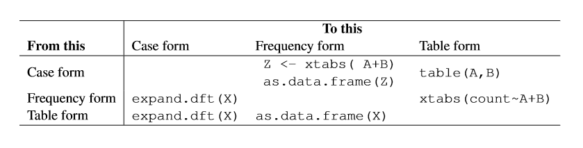

# Table Form to Frequency Form

`as.data.frame()`

- converts a contingency table in table form to a data frame in frequency form
- is the inverse of `xtabs()` which converts a data frame to a table

Returning to our General Social Survey Data. Recall, this was previously converted to a table.

```r
GSS <- data.frame(expand.grid(sex=c("female", "male"), party=c("dem", "indep", "rep")), count=c(279,165,73,47,225,191))
GSS
```

```
##      sex party count
## 1 female   dem   279
## 2   male   dem   165
## 3 female indep    73
## 4   male indep    47
## 5 female   rep   225
## 6   male   rep   191
```

# Table Form to Frequency Form

```r
GSStab <- xtabs(count ~ sex + party, data=GSS)
#convert GSS table to data frame
GSStab <- as.data.frame(GSStab)
head(GSStab)    #Freq is the default name given to the count variable in the dataframe
```

```
##      sex party Freq
## 1 female   dem  279
## 2   male   dem  165
## 3 female indep   73
## 4   male indep   47
## 5 female   rep  225
## 6   male   rep  191
```

# Case Form to Table Form

`table()`

- converts case form to table form

Remember from section 2.4, `table()` does not have a data= argument and you select the variables by directly specifying them or using index notation.

Let’s revisit the Arthritis treatment data.

```r
#convert data frame to table
str(table(Arthritis[c("Treatment", "Sex", "Improved")]))
```

```
##  'table' int [1:2, 1:2, 1:3] 19 6 10 7 7 5 0 2 6 16 ...
##  - attr(*, "dimnames")=List of 3
##   ..$ Treatment: chr [1:2] "Placebo" "Treated"
##   ..$ Sex      : chr [1:2] "Female" "Male"
##   ..$ Improved : chr [1:3] "None" "Some" "Marked"
```

```r
#performs same as above using index notation
str(table(Arthritis[, c (2, 3, 5)]))
```

```
##  'table' int [1:2, 1:2, 1:3] 19 6 10 7 7 5 0 2 6 16 ...
##  - attr(*, "dimnames")=List of 3
##   ..$ Treatment: chr [1:2] "Placebo" "Treated"
##   ..$ Sex      : chr [1:2] "Female" "Male"
##   ..$ Improved : chr [1:3] "None" "Some" "Marked"
```

# Next Homework

- Review Expectations